# Genetics of common complex psychiatric disorders I

Mark James Adams

# Part 1: Biometrics

Mark James Adams  
Division of Psychiatry  
`mark.adams@ed.ac.uk`  
*Genetics and Environmental Influences on Behaviour and Mental Health*

# What is a *“common”*, *“complex”* psychiatric disorder?

**Common:** Affects 1% or more of the population  
**Complex:** Inheritance cannot be explained by a single gene

## Psychiatric diagnoses

- Depressive disorder: Marked and persistent low mood and inability to feel pleasure.
- Anxiety disorder: Extensive, pervasive, unrealistic, and disabling worry.
- Bipolar disorder: Intense mood swings between mania and depression.
- Schizophrenia: Peristent hallucinations and delusions that severely impair functioning, highly disorganised thought and speech.
- Eating disorders: self-starvation or excessive over-eating, debilitating preoccupation with body image.
- Attention-deficit/hyperactivity disorder: Early onset, developmentally inappropriate and persistant hyperactivity and inattention.
- Autism spectrum disorders: Markedly impaired interpersonal interactions, non-goal-directed behaviours, and language development.

## Prevalences

# Why genetics?

Why use genetics to study mental health and psychiatric disorders?

- Biological understanding of genes, pathways
- Shared aetiology with other disorders
- Risk prediction
- Drug retargeting
- Causal analysis of environmental risk factors

## Genetics of categorical traits

[figure not shown]

Diagram showing the seven “characters” observed by Mendel

## Genetics of continuous traits

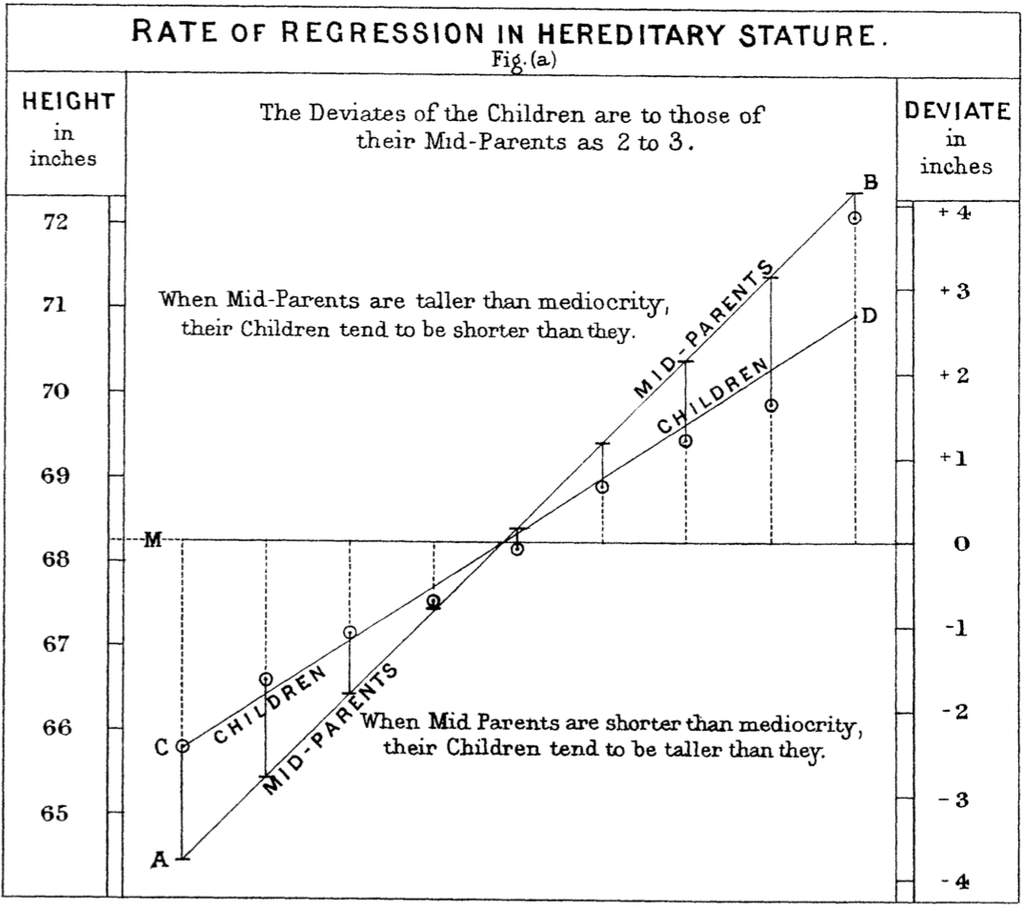

## Reconciling categorical + continuous genetics = quantitative genetics

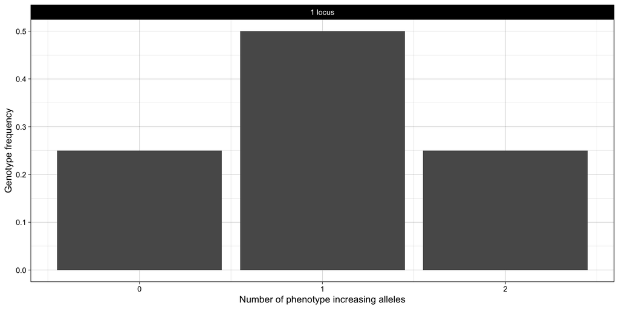

## Single locus with additive effect

Single locus with two alleles, $\mathrm{A}_1$ and $\mathrm{A}_2$, and four genotypes with values:

- $\mathrm{A}_1\mathrm{A}_1$: $2a$
- $\mathrm{A}_1\mathrm{A}_2$ and $\mathrm{A}_2\mathrm{A}_1$: $a$
- $\mathrm{A}_2\mathrm{A}_2$: $0$

If allele $\mathrm{A}_1$ has a frequency of $p$ and $\mathrm{A}_2$ has frequency $1-p$, then the genotype frequencies are:

- $\mathrm{A}_1\mathrm{A}_1$: $p^2$
- $\mathrm{A}_1\mathrm{A}_2$ and $\mathrm{A}_2\mathrm{A}_1$: $2p(1-p)$
- $\mathrm{A}_2\mathrm{A}_2$: $(1-p^2)$

| Genotype | Frequency | Value | Freq. $\times$ Val. |
| --- | --- | --- | --- |
| $\mathrm{A}_1\mathrm{A}_1$ | $p^2$ | $2a$ | $2p^2a$ |
| $\mathrm{A}_1\mathrm{A}_2$ | $p(1-p)$ | $a$ | $p(1-p)a$ |
| $\mathrm{A}_2\mathrm{A}_1$ | $p(1-p)$ | $a$ | $p(1-p)a$ |
| $\mathrm{A}_2\mathrm{A}_2$ | $(1-p)^2$ | $0$ | $0$ |
|  |  | Mean = | $2pa$ |
|  |  | Variance = | $2p(1-p)a^2$ |

## Genetic values

Each individual $i$ has a genetic value at locus $j$:

$$g_{ij} \in [0, a_j, 2a_j]$$

Total genetic value from $M$ loci:

$$G_i = \sum_{j = 1}^M g_{ij}$$

$$\mathrm{var}(G) = \sum_{j = 1}^M 2p_j(1-p_j)a_j^2$$

## Polygenic traits are quantitative traits

Adding up effects from a large number of genetic loci makes a continuous phenotype.

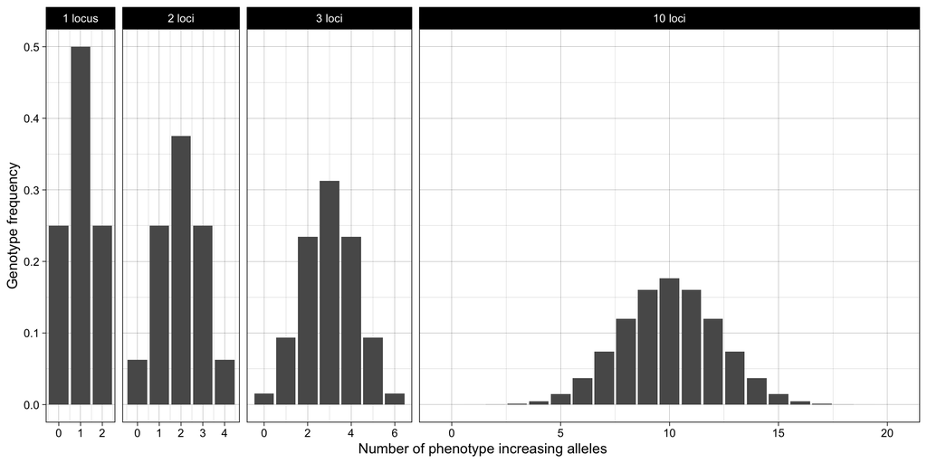

# Biometrics

## What are the sources of family resemblance? How do we quantify them numerically?

## Heritability

Proportion of similarity in phenotypes that can be attributed to similarity in genotypes.

**Model:** Phenotype (P) = Genotype (G) + Environment (E)
**Variance decomposition**
$$\mathrm{var}(P) = \mathrm{var}(G) + \mathrm{var}(𝐸)$$

**Proportion of variance**
$$H^2 = \frac{\mathrm{var}(G)}{\mathrm{var}(𝑃)}, e^2 = \frac{\mathrm{var}(E)}{\mathrm{var}(𝑃)}, H^2 + e^2 = 1$$

## How to estimate heritability from data

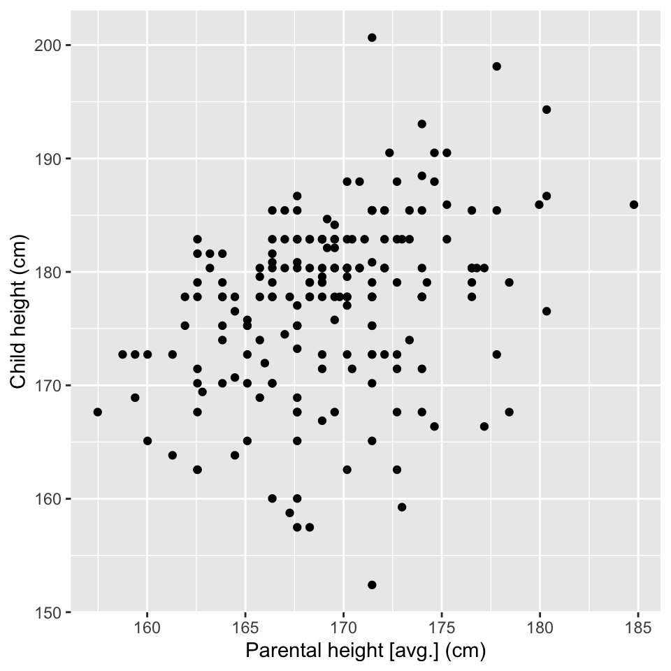

Plot of child (offspring) height versus the average of their parents’ heights. What is a statistic that can be used to summarise the relationship between these two variables?

## How to estimate heritability from data

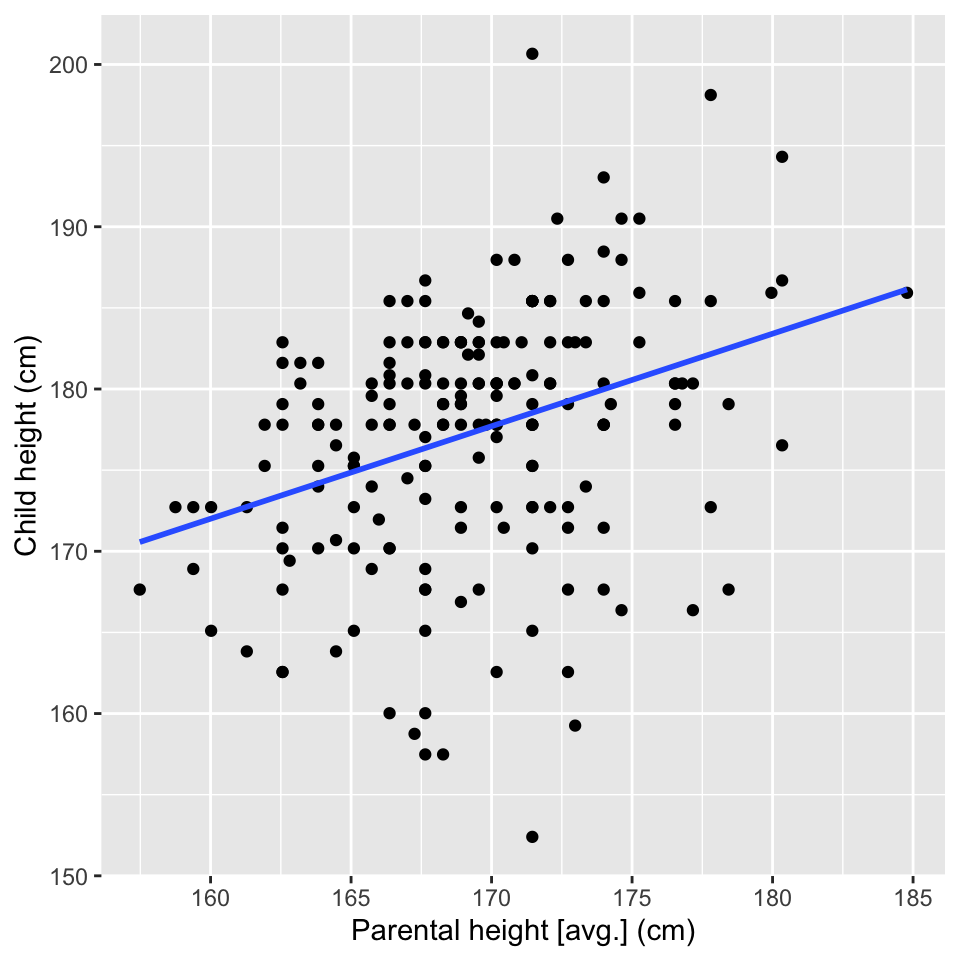

$\beta = \frac{\mathrm{cov}(X, Y)}{\mathrm{var}(X)}$

Estimate the beta coefficient (slope) for a simple regression from the covariance between predictor ($X$) and outcome ($Y$) variable divided by the variance of the predictor ($X$).

## Simple model of genetic and environmental effects

$$P = A + E$$

The phenotype value $P$ is influenced by an additive genetic effect $A$ and and environmental effect $E$.

## Simple model of genomics

$$A = a_{m_t} + a_{p_t}$$

Each individual has two copies of the genome, one inherited from each parent.

## Simple model of inheritance

[figure not shown]

## Simple model of genetics, environment, and inheritance

Phenotype ($P$) value is the sum of the two genetic values plus an environmental value ($e$).

- Mother’s phenotype (maternal): $P_m = a_{m_t} + a_{m_{nt}} + e_m$
- Father’s phenotype (paternal): $P_p = a_{p_t} + a_{p_{nt}}+ e_p$
- Child’s phenotype (offspring): $P_o = a_{m_t} + a_{p_t} + e_o$

## Regression equation

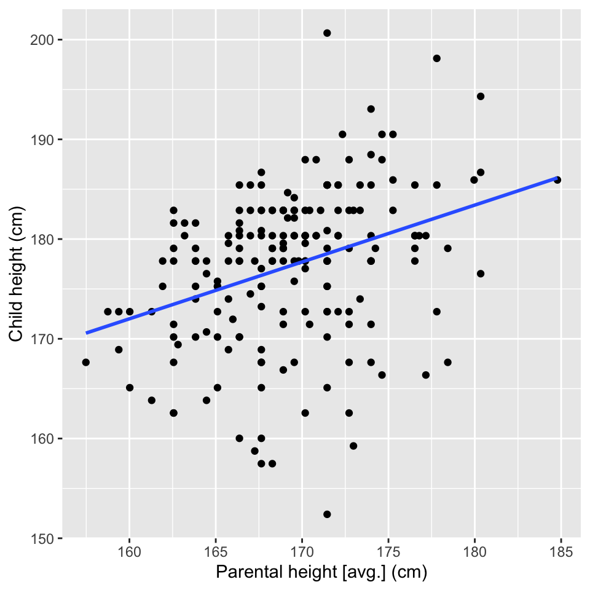

$\beta = \frac{\mathrm{cov}(X, Y)}{\mathrm{var}(X)}$

- $X$ = average of parents’ phenotypes
- $Y$ = offspring phenotype

Therefore, $\beta = \frac{\mathrm{cov}(\frac{P_m + P_p}{2}, P_o)}{\mathrm{var}(\frac{P_m + P_p}{2})}$

## Parent–offspring covariance

$$\mathrm{cov}(\frac{P_m + P_p}{2}, P_o)$$

## Simple genetic model

[figure not shown]

## Parent–offspring covariance

The only contribution to the covariance between parent and offspring phenotypes are the transmitted parental genetic effects, which each make up half of the genetic variance.

$$\begin{eqnarray}
& \mathrm{cov}(\frac{P_m + P_p}{2}, P_o) \\
= & \mathrm{cov}(\frac{P_m}{2}, P_o) + \mathrm{cov}(\frac{P_p}{2}, P_o) \\
= & \frac{1}{2} \mathrm{cov}(P_m, P_o) + \frac{1}{2} \mathrm{cov}(P_p, P_o) \\
= & \frac{1}{2} \mathrm{cov}(a_{m_t}, a_{m_t}) + \frac{1}{2} \mathrm{cov}(a_{p_t}, a_{p_t}) \\
= & \frac{1}{2} \mathrm{var}(a_{m_t}) + \frac{1}{2} \mathrm{var}(a_{p_t})\\
= & \frac{1}{2} (\frac{1}{2} V_A) + \frac{1}{2} (\frac{1}{2} V_A) \\
= & \frac{1}{2} V_A
\end{eqnarray}$$

## Average parental variance

$$\mathrm{var}(\frac{P_m + P_p}{2})$$

## Average parental variance

$$\mathrm{var}(\frac{P_m + P_p}{2})$$

$$\begin{eqnarray}
& = \mathrm{var}(\frac{P_m + P_p}{2}) \\
& = \mathrm{var}(\frac{P_m}{2}) + \mathrm{var}(\frac{P_p}{2}) \\
& = \frac{1}{4}\mathrm{var}(P_m) + \frac{1}{4} \mathrm{var}(P_p) \\
& = \frac{1}{4} V_P + \frac{1}{4} V_P \\
& = \frac{1}{2} V_P
\end{eqnarray}$$

## Putting it all together.

The regression beta estimate is:
$$\beta = \frac{\mathrm{cov}(\frac{P_m + P_p}{2}, P_o)}{\mathrm{var}(\frac{P_m + P_p}{2})}$$

Thus

$$\begin{eqnarray}
\beta & = \frac{\frac{1}{2} V_A} {\frac{1}{2} V_P} \\
& = \frac{V_A}{V_P} \\
& = h^2
\end{eqnarray}$$

## Height data

$\mathrm{cov}(\frac{P_d + P_s}{2}, P_o) =$ 12.57  
$\mathrm{var}(\frac{P_d + P_s}{2}) =$ 22.04  
$\hat{h}^2 =$ 12.57 / 22.04 = 0.57

Parent and offspring phenotypes become more highly correlated as heritability increases.

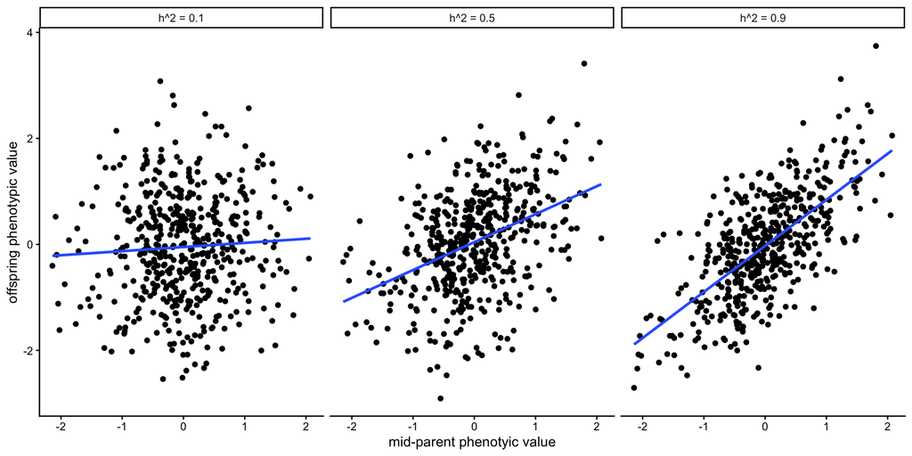

**Mini review: What assumptions have we made when estimating $h^2$?**

[figure not shown]

## Generalising to other relatives

Heritability can also be estimated from resemblance between different types of related pairs. The general equation is:

$$h^2 = \frac{b}{\mathrm{r}}$$

$b$ = regression coefficient  
$\mathrm{r}$ = relatedness coefficient (“coefficient of additive variance”)

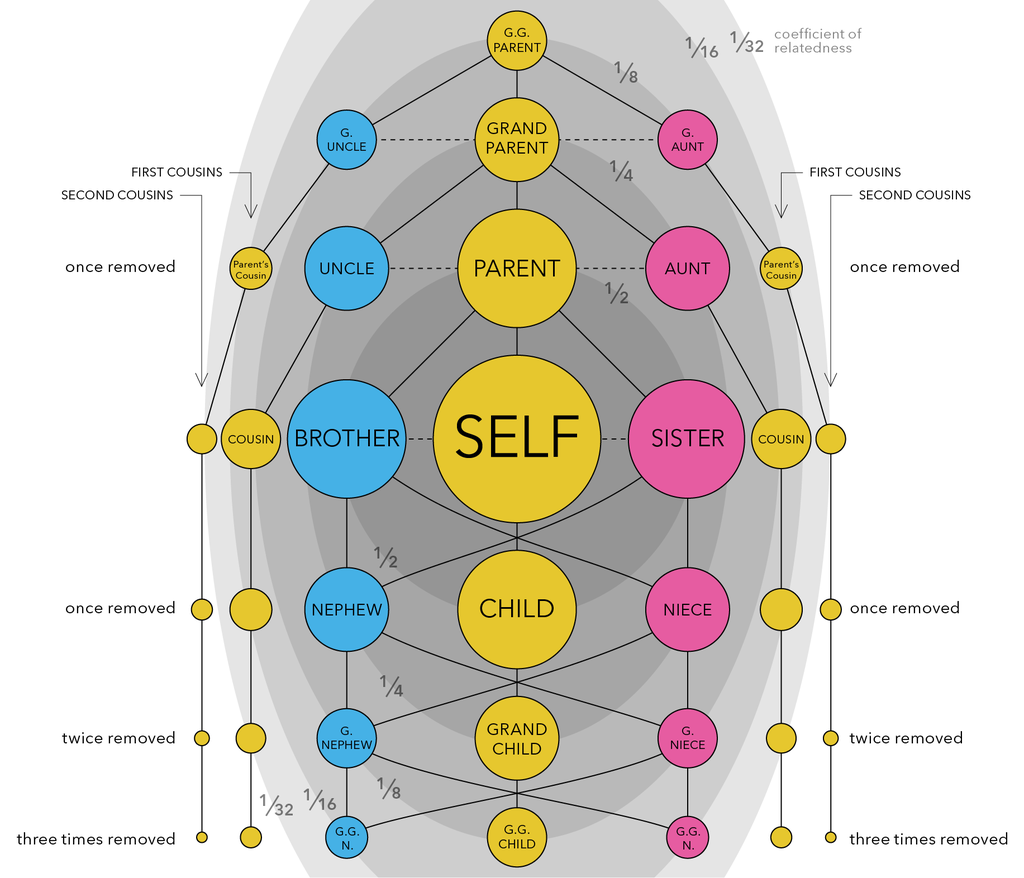

## Example data: depression scores

Correlation of depression scores for different pairs of relatives

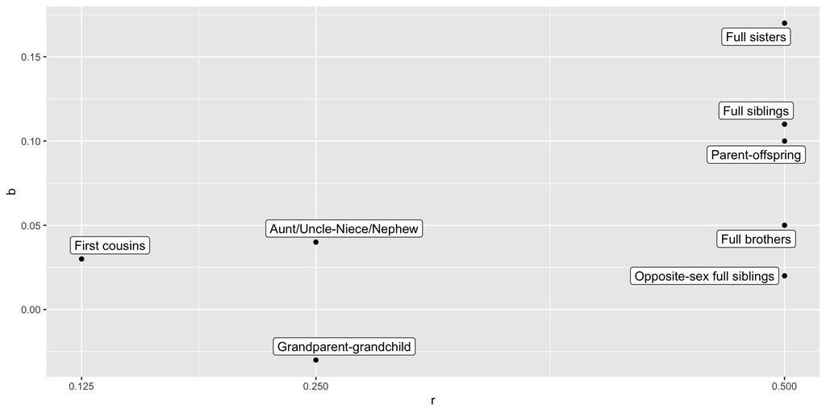

## Recurrance risk to relatives

$$\lambda_\mathrm{R} = \frac{P(\mathrm{affected} | \mathrm{relative\ affected})}{P(\mathrm{affected\ in\ population})} = \frac{K_\mathrm{R}}{K}$$

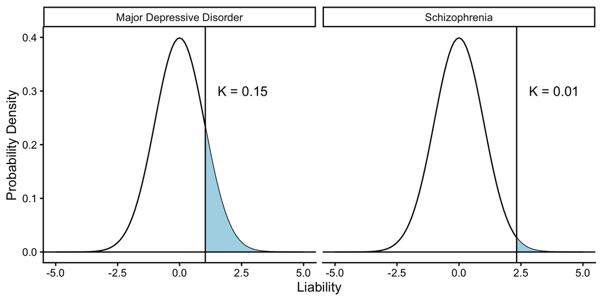

Example:

- $K_\mathrm{sib} = P(\mathrm{affected} | \mathrm{sibling\ affected}) = 0.09$
- $K = P(\mathrm{affected\ in\ population}) = 0.02$
- $\frac{K_\mathrm{sib}}{K} = \frac{0.09}{0.02} = 4.5$

## Recurrance risk for schizophrenia

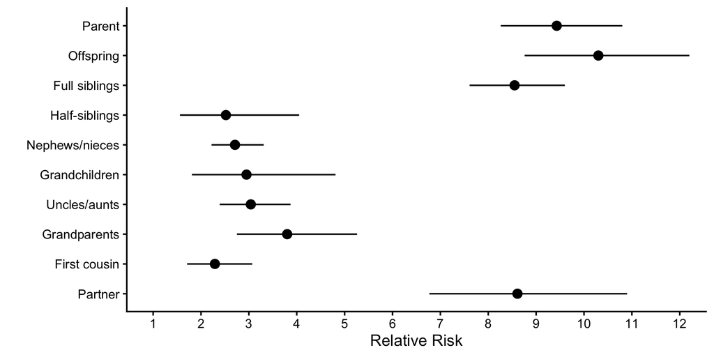

## Recurrance risk and heritability

- Score $\mathrm{unaffected} = 0, \mathrm{affected} = 1$
- If population prevalence is $K$, then phenotypic variance is $V_\mathrm{P} = K(1-K)$ (Bernoulli distribution)
- $Y$ = score of individual (proband)
- $Y_\mathrm{R}$ = score of relative of proband
- Expectation: $E[Y] = E[Y_\mathrm{R}] = K$
- $K_\mathrm{R} = E[Y_\mathrm{R} | Y = 1]$
- Probability that both $Y$ and $Y_\mathrm{R}$ = 1: $E[YY_\mathrm{R}] = K \times K_\mathrm{R}$

$$\mathrm{cov}(Y, Y_\mathrm{R}) = E[YY_\mathrm{R}] - E[Y] E[Y_\mathrm{R}] \\
= K \times K_\mathrm{R} - K^2 \\$$

$$\mathrm{cov}(Y, Y_\mathrm{R}) = E[YY_\mathrm{R}] - E[Y] E[Y_\mathrm{R}]$$

$$= K \times K_\mathrm{R} - K^2 \\
= K(K_\mathrm{R} - K) \\
= K^2 (\frac{K_\mathrm{R}}{K} - 1) \\
= K^2 (\lambda_\mathrm{R} - 1)$$

## Heritability estimate

$$h^2 = \frac{\mathrm{cov}_\mathrm{R}}{\mathrm{r}V_\mathrm{P}} \\
= \frac{K^2 (\lambda_\mathrm{R} - 1)}{\mathrm{r}K(1-K)} \\
= \frac{K (\lambda_\mathrm{R} - 1)}{\mathrm{r}(1-K)} \\$$

## Recurrance risk of psychiatric disorders

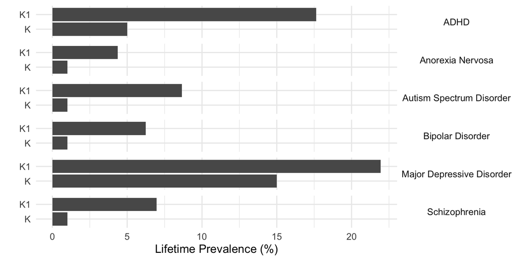

Prevalence in population (K) and with one parent affected (K[1])

## Estimating environmental effects

Contrast pairs of relatives that have comparable environmental similarity but different genetic similarity.

[figure not shown]

- Monozygotic (MZ) twins $\mathrm{r} = 1.0$
- Dizygotic (DZ) twins $\mathrm{r} = 0.5$

## Additive genetic and shared environment effects

Add a shared ($C$ or “common”) environment to the basic genetic model, to capture similarity between relatives attributable to environmental factors. $E$ represents the unique, non-shared environment.

$$P = A + C + E$$

$$h^2 = \frac{\mathrm{var}(A)}{\mathrm{var}(P)}, c^2 = \frac{\mathrm{var}(C)}{\mathrm{var}(P)}, e^2 = \frac{\mathrm{var}(E)}{\mathrm{var}(P)}$$

$$h^2 + c^2 + e^2 = 1$$

## Twin correlations

MZ twins: $r_\mathrm{MZ} = h^2 + c^2$

DZ twins: $r_\mathrm{DZ} = \frac{1}{2}h^2 + c^2$

### Solve for genetic similarity ($h^2$)

Calculate difference between MZ and DZ correlations

$$r_\mathrm{MZ} - r_\mathrm{DZ} = (h^2 + c^2) - (\frac{1}{2}h^2 + c^2)$$

$$r_\mathrm{MZ} - r_\mathrm{DZ} = h^2 - \frac{1}{2}h^2 + c^2 - c^2$$

$$r_\mathrm{MZ} - r_\mathrm{DZ} = \frac{1}{2}h^2$$

$$h^2 = 2(r_\mathrm{MZ} - r_\mathrm{DZ})$$

Substitute $h^2$ into MZ equation and solve for shared environment similarity ($c^2$)

$$r_\mathrm{MZ} = \underbrace{h^2} + c^2$$

$$r_\mathrm{MZ} = 2(r_\mathrm{MZ} - r_\mathrm{DZ}) + c^2$$

$$r_\mathrm{MZ} - 2(r_\mathrm{MZ} - r_\mathrm{DZ}) = c^2$$

$$c^2 = r_\mathrm{MZ} - 2r_\mathrm{MZ} + 2r_\mathrm{DZ}$$

$$c^2 = 2r_\mathrm{DZ} - r_\mathrm{MZ}$$

Therefore from MZ and DZ twin correlations we can estimate:

$$h^2 = 2(r_\mathrm{MZ} - r_\mathrm{DZ}) \\
c^2 = 2r_\mathrm{DZ} - r_\mathrm{MZ} \\
e^2 = 1 - h^2 - c^2$$

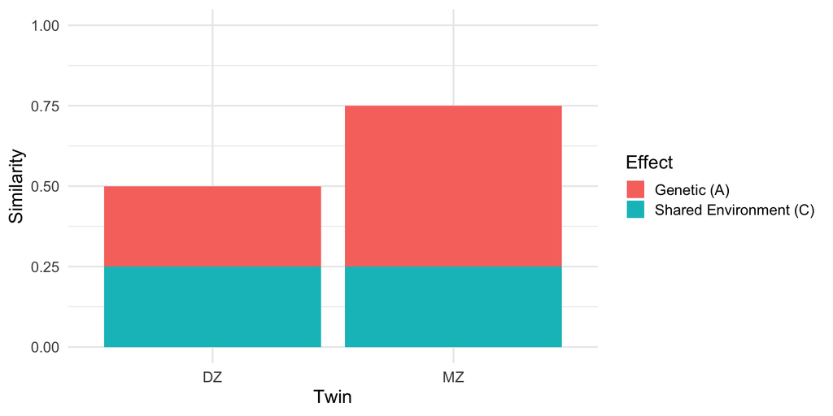

Visualisation with *r*[MZ] = 0.75 and *r*[DZ] = 0.5.

## What do we know about psychiatric genetics from twins studies

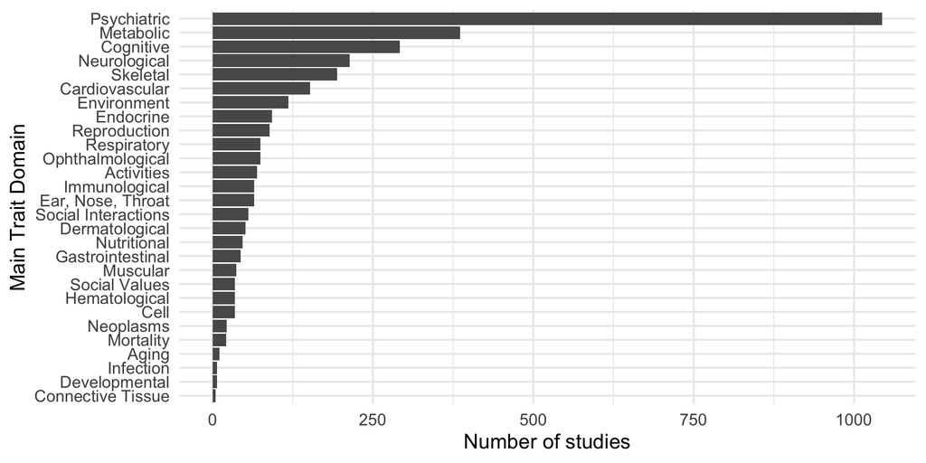

## Meta-analysis of twin heritability

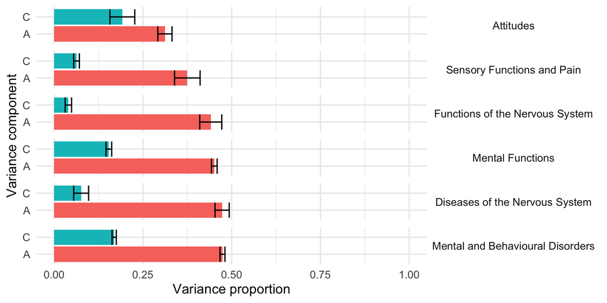

Meta-analysis of phenotype domains

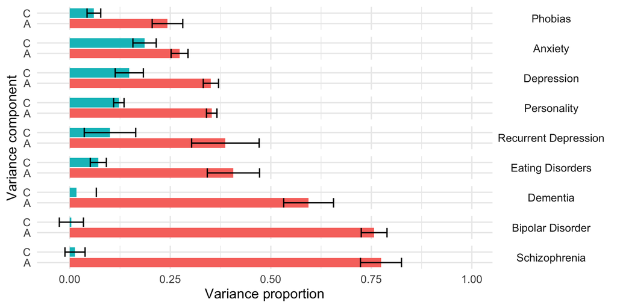

Meta-analysis of psychiatric, neurological, and psychological phenotypes

# Genetics of depression and schizophrenia

## Major depressive disorder (MDD)

- 1+ in 10 affected
- 7-11 years of life are lost
- Global cause of ill-health

## MDD diagnostic criteria

1 of the 2 **cardinal** symptoms with 5 symptoms in total:

1. **Low mood**
2. **Anhedonia**
3. Increase or decrease in weight or appetite
4. Insomnia or hypersomnia
5. Psychomotor agitation or slowing
6. Fatigue
7. Feelings of worthlessness/guilt
8. Concentration problems
9. Suicidal ideation

Heterogeneous disorder: 227 possible symptom profiles.

## “Evidence for Multiple Genetic Factors Underlying DSM-IV Criteria for Major Depression”

[output not shown]

## Multivariate twin model

- analysed MZ and DZ twin cross-correlations among depression symptoms
- tested 1, 2, or 3 factor models of genetic, shared environment, and unique environment

## Best fit model

**Genetic factors**

1. Psychomotor/cognitive symptoms (psychomotor, guilt, concentration, suicidality)
2. Mood symptoms (low mood, anhedonia)
3. Neurovegetative symptoms (weight, sleep, fatigue)

**Individual-specific (unique) environment factors**

1. General depression (low mood, anhedonia, weight, sleep, psychomotor, fatigue, concentration)
2. Mood symptoms (low mood, anhedonia, concentration)
3. Cognitive symptoms (guilt, suicidality)

## External validators of genetic factor scores

Data from Table 4 Kendler, Aggen, & Neale. *p* < 0.001

| Validator variable | Cognitive/Motor | Core Mood | Neurovegetative |
| --- | --- | --- | --- |
| Neuroticism | **0.54** | **0.27** | **0.30** |
| Anxiety disorder | **0.77** | **0.49** | **0.47** |
| Age at onset | **-3.00** | -1.15 | 0.37 |
| No. of episodes | **0.55** | 0.16 | **0.23** |
| Melancholia subtype | **1.05** | **-0.43** | **1.34** |
| Unreactive mood | **0.82** | 0.10 | **0.79** |

## Schizophrenia diagnostic criteria

At least one **core** symptom and two or more symptoms present for a significant period of time

1. **Delusions**
2. **Hallucinations**
3. **Disorganised speech**
4. Grossly disorganised or catatonic behaviour
5. Negative symptoms

## Schizophrenia risk factors

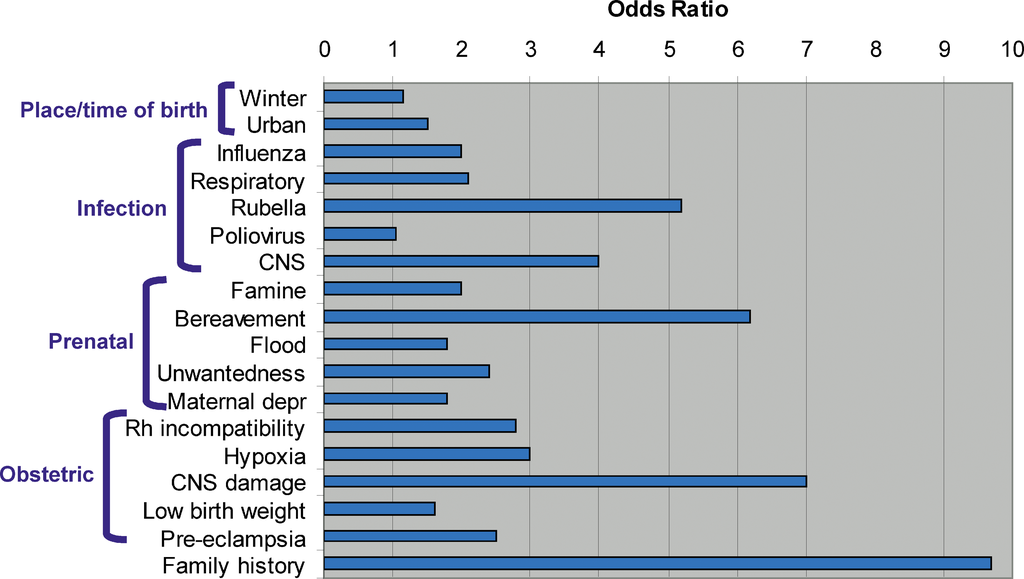

# Why is $h^2$ the symbol for heritability?

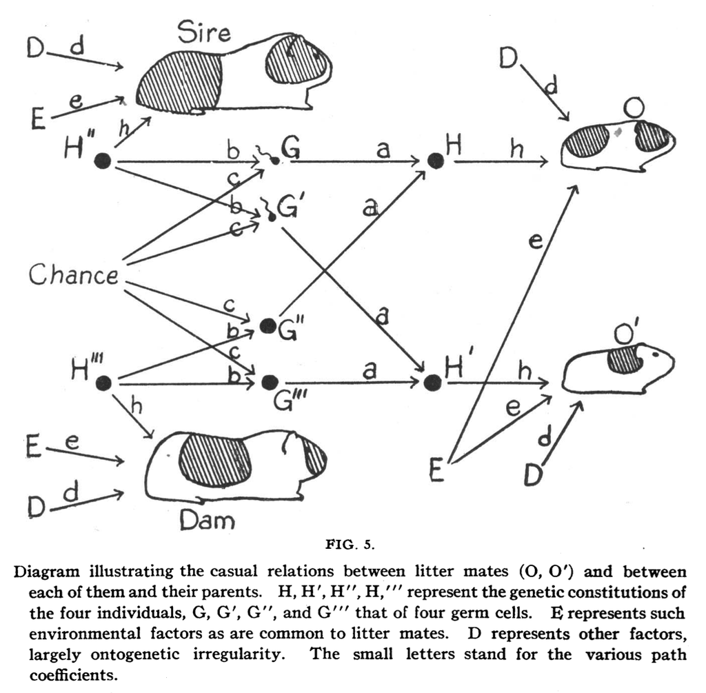

# Coda: Longer derivation of parent-offspring covariance (optional material)

## Parent–offspring covariance

$$\mathrm{cov}(\frac{P_m + P_p}{2}, P_o)$$

$$= \mathrm{cov}(\frac{a_{m_{t}} + a_{m_{nt}} + e_m + a_{p_{t}} + a_{p_{nt}}+ e_p}{2}, a_{m_{t}} + a_{p_{t}} + e_o)$$

## Parent-offspring covariance

Expand the terms. Recall that:

$$\mathrm{cov}(A+X,B+Y) = \\
\mathrm{cov}(A,B) + \mathrm{cov}(A,Y) + \mathrm{cov}(X,B) + \mathrm{cov}(X,Y)$$
Thus we can do a pairwise expansion to:
$$= \mathrm{cov}(\frac{a_{m_{t}}}{2} + \frac{a_{m_{nt}}}{2} + \frac{e_d}{2} + \frac{a_{p_t}}{2} + \frac{a_{p_{nt}}}{2} + \frac{e_s}{2}, a_{m_t} + a_{p_t} + e_o)$$
$$= \mathrm{cov}(\frac{a_{m_{t}}}{2}, a_{m_{t}}) + \mathrm{cov}(\frac{a_{m_{nt}}}{2}, a_{m_{t}}) + \dotsm+ \mathrm{cov}(\frac{e_p}{2}, e_o)$$

## Simplifications

Some terms can be simplified.

Simplifies to:

$$\mathrm{cov}(\frac{a_{m_{t}}}{2}, a_{m_{t}}) = \frac{1}{2}\mathrm{cov}(a_{m_{t}}, a_{m_{t}}) = \frac{1}{2}\mathrm{var}(a_{m_{t}})$$
$$\mathrm{cov}(\frac{a_{p_t}}{2}, a_{p_t}) = \frac{1}{2}\mathrm{cov}(a_{p_t}, a_{p_t}) = \frac{1}{2}\mathrm{var}(a_{p_t})$$

## Assumptions

For some terms we might make an assumption that they are equal to 0.

*Covariance between genetic effects from the same parent*
$$\mathrm{cov}(\frac{a_{m_{nt}}}{2}, a_{m_{t}}), \mathrm{cov}(\frac{a_{p_{nt}}}{2}, a_{p_t})$$

*Covariance between genetic effects from different parents*
$$\mathrm{cov}(\frac{a_{m_{nt}}}{2}, a_{p_t}), \mathrm{cov}(\frac{a_{p_{nt}}}{2}, a_{m_{t}})$$

*Covariance between parent and offspring environment effects*
$$\mathrm{cov}(\frac{e_m}{2}, e_o), \mathrm{cov}(\frac{e_p}{2}, e_o)$$

*Covariance between parental genetic and offspring environmental effects*
$$\mathrm{cov}(\frac{a_{m_{t}}}{2}, e_o), \mathrm{cov}(\frac{a_{p_t}}{2}, e_o)$$

Using those assumptions the parent–offspring covariance simplifies to

$$\mathrm{cov}(\frac{P_m + P_p}{2}, P_o) = \frac{\mathrm{var}(a_{m_{t}}) + \mathrm{var}(a_{p_t})}{2}$$

## Parent variance

The denominator in the regression equation was
$$\mathrm{var}(\frac{P_m + P_p}{2})$$

Using the identity
$$\mathrm{var}(aX + bY) = a^2\mathrm{var}(X) + b^2\mathrm{var}(Y) + 2ab\mathrm{cov}(X, Y)$$
the variance of the average parental phenotypes is:
$$\mathrm{var}(\frac{P_m + P_p}{2}) = \mathrm{var}(\frac{1}{2}P_m + \frac{1}{2} P_p)$$
$$= \left(\frac{1}{2}\right)^2\mathrm{var}(P_m) + \left(\frac{1}{2}\right)^2\mathrm{var}(P_p) + 2 \cdot \frac{1}{2} \cdot \frac{1}{2} \mathrm{cov}(P_m, P_p)$$
$$= \frac{1}{4}\mathrm{var}(P_m) + \frac{1}{4}\mathrm{var}(P_p) + \frac{1}{2} \mathrm{cov}(P_m, P_p)$$

If we assume as above that there is no covariation between parental effects ($\mathrm{cov}(P_m, P_p) = 0$), this simplifies to

$$= \frac{\mathrm{var}(P_m) + \mathrm{var}(P_p)}{4}$$

Thus the regression equation is:

$$\beta = \frac{\mathrm{cov}(\frac{P_m + P_p}{2}, P_o)}{\mathrm{var}(\frac{P_m + P_p}{2})} \\
= \frac{\frac{\mathrm{var}(a_{m_{t}}) + \mathrm{var}(a_{p_t})}{2}}{\frac{\mathrm{var}(P_m) + \mathrm{var}(P_p)}{4}} \\
= 2\frac{\mathrm{var}(a_{m_{t}}) + \mathrm{var}(a_{p_t})}{\mathrm{var}(P_m) + \mathrm{var}(P_p)}$$

Previously we defined

$$A = a_{m_t} + a_{p_t}$$
thus
$$\mathrm{var}(A) = \mathrm{var}(a_{m_{t}}) + \mathrm{var}(a_{p_t})$$
and assume variances in parental phenotypes are equal
$$\mathrm{var}(P_m) = \mathrm{var}(P_s) = \mathrm{var}(P)$$

Then substitute into the regression equation

$$\beta = 2\frac{\mathrm{var}(a_{m_{t}}) + \mathrm{var}(s)}{\mathrm{var}(P_d) + \mathrm{var}(P_s)} \\
= 2 \frac{\mathrm{var}(A)}{\mathrm{var}(P) + \mathrm{var}(P)} \\
= 2 \frac{\mathrm{var}(A)}{2 \mathrm{var}(P)} \\
= \frac{\mathrm{var}(A)}{\mathrm{var}(P)} \\
= h^2$$